# Risk Factor Analysis

## Outcome Variable

**Outcome Variable:** stunted

## Predictor Variables

**Intervention Variable:** perdiar24

**Adjustment Set:**

- arm
- sex
- meducyrs
- feducyrs
- hhwealth_quart
- hfoodsec
- vagbrth
- hdlvry
- W_birthwt
- W_birthlen
- single
- W_nrooms
- month
- brthmon
- impfloor
- impsan
- safeh20
- delta_meducyrs
- delta_feducyrs
- delta_hhwealth_quart
- delta_hfoodsec
- delta_vagbrth
- delta_hdlvry
- delta_W_birthwt
- delta_W_birthlen
- delta_single
- delta_W_nrooms
- delta_month
- delta_brthmon
- delta_impfloor
- delta_impsan
- delta_safeh20

## Stratifying Variables

The analysis was stratified on these variable(s):

- agecat
- studyid
- country

## Data Summary

| agecat | studyid | country | perdiar24 | stunted | n_cell | n |
| --- | --- | --- | --- | --- | --- | --- |
| Birth | CMIN | BANGLADESH | 0% | 0 | 6 | 26 |
| Birth | CMIN | BANGLADESH | 0% | 1 | 6 | 26 |
| Birth | CMIN | BANGLADESH | (0%, 5%] | 0 | 3 | 26 |
| Birth | CMIN | BANGLADESH | (0%, 5%] | 1 | 1 | 26 |
| Birth | CMIN | BANGLADESH | >5% | 0 | 8 | 26 |
| Birth | CMIN | BANGLADESH | >5% | 1 | 2 | 26 |
| Birth | CONTENT | PERU | 0% | 0 | 0 | 2 |
| Birth | CONTENT | PERU | 0% | 1 | 0 | 2 |
| Birth | CONTENT | PERU | (0%, 5%] | 0 | 1 | 2 |
| Birth | CONTENT | PERU | (0%, 5%] | 1 | 0 | 2 |
| Birth | CONTENT | PERU | >5% | 0 | 1 | 2 |
| Birth | CONTENT | PERU | >5% | 1 | 0 | 2 |
| Birth | EE | PAKISTAN | 0% | 0 | 88 | 240 |
| Birth | EE | PAKISTAN | 0% | 1 | 73 | 240 |
| Birth | EE | PAKISTAN | (0%, 5%] | 0 | 52 | 240 |
| Birth | EE | PAKISTAN | (0%, 5%] | 1 | 27 | 240 |
| Birth | EE | PAKISTAN | >5% | 0 | 0 | 240 |
| Birth | EE | PAKISTAN | >5% | 1 | 0 | 240 |
| Birth | JiVitA-4 | BANGLADESH | 0% | 0 | 50 | 2823 |
| Birth | JiVitA-4 | BANGLADESH | 0% | 1 | 26 | 2823 |
| Birth | JiVitA-4 | BANGLADESH | (0%, 5%] | 0 | 1720 | 2823 |
| Birth | JiVitA-4 | BANGLADESH | (0%, 5%] | 1 | 729 | 2823 |
| Birth | JiVitA-4 | BANGLADESH | >5% | 0 | 196 | 2823 |
| Birth | JiVitA-4 | BANGLADESH | >5% | 1 | 102 | 2823 |
| Birth | MAL-ED | BANGLADESH | 0% | 0 | 13 | 231 |
| Birth | MAL-ED | BANGLADESH | 0% | 1 | 5 | 231 |
| Birth | MAL-ED | BANGLADESH | (0%, 5%] | 0 | 112 | 231 |
| Birth | MAL-ED | BANGLADESH | (0%, 5%] | 1 | 19 | 231 |
| Birth | MAL-ED | BANGLADESH | >5% | 0 | 62 | 231 |
| Birth | MAL-ED | BANGLADESH | >5% | 1 | 20 | 231 |

[output cut: 234 more lines]

The following strata were considered:

- agecat: 24 months, studyid: CMIN, country: BANGLADESH
- agecat: 24 months, studyid: CONTENT, country: PERU
- agecat: 24 months, studyid: EE, country: PAKISTAN
- agecat: 24 months, studyid: JiVitA-4, country: BANGLADESH
- agecat: 24 months, studyid: MAL-ED, country: BANGLADESH
- agecat: 24 months, studyid: MAL-ED, country: BRAZIL
- agecat: 24 months, studyid: MAL-ED, country: INDIA
- agecat: 24 months, studyid: MAL-ED, country: NEPAL
- agecat: 24 months, studyid: MAL-ED, country: PERU
- agecat: 24 months, studyid: MAL-ED, country: SOUTH AFRICA
- agecat: 24 months, studyid: MAL-ED, country: TANZANIA, UNITED REPUBLIC OF
- agecat: 24 months, studyid: NIH-Birth, country: BANGLADESH
- agecat: 24 months, studyid: NIH-Crypto, country: BANGLADESH
- agecat: 24 months, studyid: PROVIDE, country: BANGLADESH
- agecat: 6 months, studyid: CMIN, country: BANGLADESH
- agecat: 6 months, studyid: CONTENT, country: PERU
- agecat: 6 months, studyid: EE, country: PAKISTAN
- agecat: 6 months, studyid: Guatemala BSC, country: GUATEMALA
- agecat: 6 months, studyid: JiVitA-4, country: BANGLADESH
- agecat: 6 months, studyid: MAL-ED, country: BANGLADESH
- agecat: 6 months, studyid: MAL-ED, country: BRAZIL
- agecat: 6 months, studyid: MAL-ED, country: INDIA
- agecat: 6 months, studyid: MAL-ED, country: NEPAL
- agecat: 6 months, studyid: MAL-ED, country: PERU
- agecat: 6 months, studyid: MAL-ED, country: SOUTH AFRICA
- agecat: 6 months, studyid: MAL-ED, country: TANZANIA, UNITED REPUBLIC OF
- agecat: 6 months, studyid: NIH-Birth, country: BANGLADESH
- agecat: 6 months, studyid: NIH-Crypto, country: BANGLADESH
- agecat: 6 months, studyid: PROVIDE, country: BANGLADESH
- agecat: 6 months, studyid: SAS-FoodSuppl, country: INDIA
- agecat: Birth, studyid: CMIN, country: BANGLADESH
- agecat: Birth, studyid: CONTENT, country: PERU
- agecat: Birth, studyid: EE, country: PAKISTAN
- agecat: Birth, studyid: JiVitA-4, country: BANGLADESH
- agecat: Birth, studyid: MAL-ED, country: BANGLADESH
- agecat: Birth, studyid: MAL-ED, country: BRAZIL
- agecat: Birth, studyid: MAL-ED, country: INDIA
- agecat: Birth, studyid: MAL-ED, country: NEPAL
- agecat: Birth, studyid: MAL-ED, country: PERU
- agecat: Birth, studyid: MAL-ED, country: SOUTH AFRICA
- agecat: Birth, studyid: MAL-ED, country: TANZANIA, UNITED REPUBLIC OF
- agecat: Birth, studyid: NIH-Birth, country: BANGLADESH
- agecat: Birth, studyid: NIH-Crypto, country: BANGLADESH
- agecat: Birth, studyid: PROVIDE, country: BANGLADESH

### Dropped Strata

- agecat: Birth, studyid: CMIN, country: BANGLADESH
- agecat: Birth, studyid: CONTENT, country: PERU
- agecat: Birth, studyid: EE, country: PAKISTAN
- agecat: Birth, studyid: MAL-ED, country: BRAZIL
- agecat: Birth, studyid: MAL-ED, country: INDIA
- agecat: Birth, studyid: MAL-ED, country: NEPAL
- agecat: Birth, studyid: MAL-ED, country: PERU
- agecat: Birth, studyid: MAL-ED, country: SOUTH AFRICA
- agecat: Birth, studyid: MAL-ED, country: TANZANIA, UNITED REPUBLIC OF
- agecat: Birth, studyid: PROVIDE, country: BANGLADESH
- agecat: 6 months, studyid: CMIN, country: BANGLADESH
- agecat: 6 months, studyid: CONTENT, country: PERU
- agecat: 6 months, studyid: EE, country: PAKISTAN
- agecat: 6 months, studyid: MAL-ED, country: BANGLADESH
- agecat: 6 months, studyid: MAL-ED, country: BRAZIL
- agecat: 6 months, studyid: MAL-ED, country: INDIA
- agecat: 6 months, studyid: MAL-ED, country: NEPAL
- agecat: 6 months, studyid: MAL-ED, country: PERU
- agecat: 6 months, studyid: MAL-ED, country: SOUTH AFRICA
- agecat: 6 months, studyid: MAL-ED, country: TANZANIA, UNITED REPUBLIC OF
- agecat: 6 months, studyid: PROVIDE, country: BANGLADESH
- agecat: 24 months, studyid: CMIN, country: BANGLADESH
- agecat: 24 months, studyid: CONTENT, country: PERU
- agecat: 24 months, studyid: EE, country: PAKISTAN
- agecat: 24 months, studyid: MAL-ED, country: BANGLADESH
- agecat: 24 months, studyid: MAL-ED, country: BRAZIL
- agecat: 24 months, studyid: MAL-ED, country: INDIA
- agecat: 24 months, studyid: MAL-ED, country: NEPAL
- agecat: 24 months, studyid: MAL-ED, country: PERU
- agecat: 24 months, studyid: MAL-ED, country: SOUTH AFRICA
- agecat: 24 months, studyid: MAL-ED, country: TANZANIA, UNITED REPUBLIC OF
- agecat: 24 months, studyid: NIH-Birth, country: BANGLADESH
- agecat: 24 months, studyid: PROVIDE, country: BANGLADESH

## Methods Detail

We’re interested in the causal parameters $E[Y_a]$ for all values of $a \in \mathcal{A}$. These parameters represent the mean outcome if, possibly contrary to fact, we intervened to set all units to have $A=a$. Under the randomization and positivity assumptions, these are identified by the statistical parameters $\psi_a=E_W[E_{Y|A,W}(Y|A=a,W)]$. In addition, we’re interested in the mean of $Y$, $E[Y]$ under no intervention (the observed mean). We will estimate these parameters by using SuperLearner to fit the relevant likelihood factors – $E_{Y|A,W}(Y|A=a,W)$ and $p(A=a|W)$, and then updating our likelihood fit using a joint TMLE.

For unadjusted analyses ($W=\{\}$), initial likelihoods were estimated using Lrnr_glm to estimate the simple $E(Y|A)$ and Lrnr_mean to estimate $p(A)$. For adjusted analyses, a small library containing Lrnr_glmnet, Lrnr_xgboost, and Lrnr_mean was used.

Having estimated these parameters, we will then use the delta method to estimate relative risks and attributable risks relative to a prespecified baseline level of $A$.

# Results Detail

## Results Plots

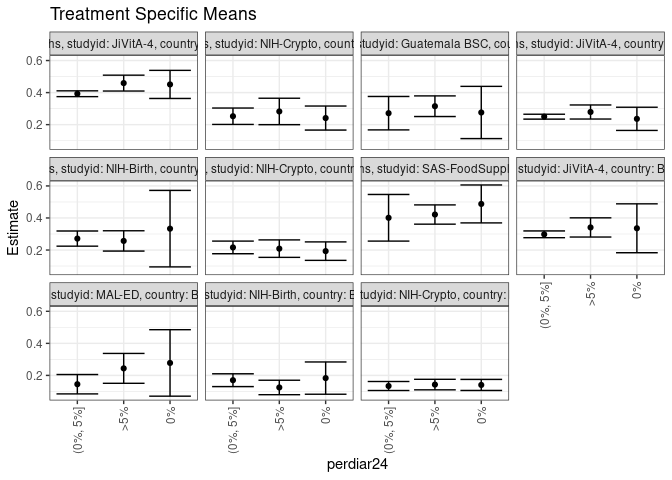

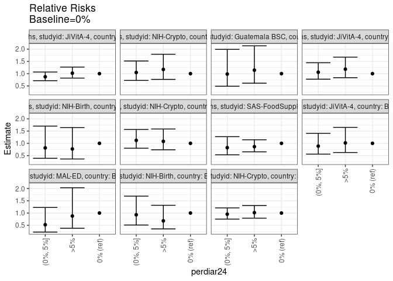

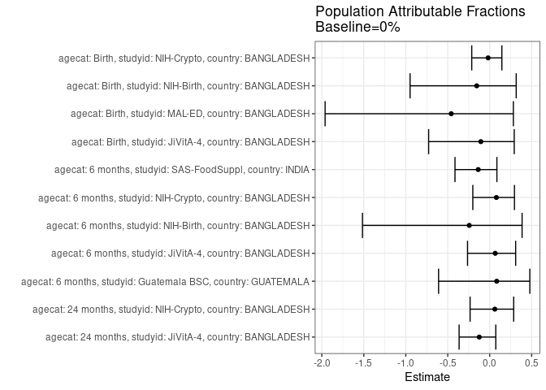

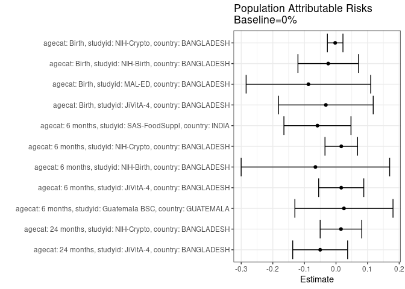

## Results Table

### Parameter: TSM

| agecat | studyid | country | intervention_level | baseline_level | estimate | ci_lower | ci_upper |
| --- | --- | --- | --- | --- | --- | --- | --- |
| Birth | JiVitA-4 | BANGLADESH | 0% | NA | 0.3356894 | 0.1830861 | 0.4882926 |
| Birth | JiVitA-4 | BANGLADESH | (0%, 5%] | NA | 0.2979961 | 0.2768430 | 0.3191492 |
| Birth | JiVitA-4 | BANGLADESH | >5% | NA | 0.3409862 | 0.2809878 | 0.4009846 |
| Birth | MAL-ED | BANGLADESH | 0% | NA | 0.2777778 | 0.0704115 | 0.4851440 |
| Birth | MAL-ED | BANGLADESH | (0%, 5%] | NA | 0.1450382 | 0.0846059 | 0.2054705 |
| Birth | MAL-ED | BANGLADESH | >5% | NA | 0.2439024 | 0.1507530 | 0.3370519 |
| Birth | NIH-Birth | BANGLADESH | 0% | NA | 0.1832398 | 0.0825059 | 0.2839738 |
| Birth | NIH-Birth | BANGLADESH | (0%, 5%] | NA | 0.1701296 | 0.1302095 | 0.2100497 |
| Birth | NIH-Birth | BANGLADESH | >5% | NA | 0.1248726 | 0.0796937 | 0.1700516 |
| Birth | NIH-Crypto | BANGLADESH | 0% | NA | 0.1405845 | 0.1061005 | 0.1750686 |
| Birth | NIH-Crypto | BANGLADESH | (0%, 5%] | NA | 0.1339179 | 0.1057846 | 0.1620512 |
| Birth | NIH-Crypto | BANGLADESH | >5% | NA | 0.1427842 | 0.1099266 | 0.1756418 |
| 6 months | Guatemala BSC | GUATEMALA | 0% | NA | 0.2758621 | 0.1129200 | 0.4388041 |
| 6 months | Guatemala BSC | GUATEMALA | (0%, 5%] | NA | 0.2714286 | 0.1670791 | 0.3757781 |
| 6 months | Guatemala BSC | GUATEMALA | >5% | NA | 0.3150000 | 0.2505146 | 0.3794854 |
| 6 months | JiVitA-4 | BANGLADESH | 0% | NA | 0.2361825 | 0.1637280 | 0.3086370 |
| 6 months | JiVitA-4 | BANGLADESH | (0%, 5%] | NA | 0.2496617 | 0.2343422 | 0.2649811 |
| 6 months | JiVitA-4 | BANGLADESH | >5% | NA | 0.2789925 | 0.2350813 | 0.3229037 |
| 6 months | NIH-Birth | BANGLADESH | 0% | NA | 0.3333333 | 0.0945517 | 0.5721150 |
| 6 months | NIH-Birth | BANGLADESH | (0%, 5%] | NA | 0.2713864 | 0.2240064 | 0.3187665 |
| 6 months | NIH-Birth | BANGLADESH | >5% | NA | 0.2568306 | 0.1934736 | 0.3201876 |
| 6 months | NIH-Crypto | BANGLADESH | 0% | NA | 0.1930868 | 0.1355149 | 0.2506587 |
| 6 months | NIH-Crypto | BANGLADESH | (0%, 5%] | NA | 0.2162740 | 0.1768189 | 0.2557291 |
| 6 months | NIH-Crypto | BANGLADESH | >5% | NA | 0.2086124 | 0.1541782 | 0.2630465 |
| 6 months | SAS-FoodSuppl | INDIA | 0% | NA | 0.4876579 | 0.3693785 | 0.6059372 |
| 6 months | SAS-FoodSuppl | INDIA | (0%, 5%] | NA | 0.4011701 | 0.2556858 | 0.5466544 |
| 6 months | SAS-FoodSuppl | INDIA | >5% | NA | 0.4215290 | 0.3614721 | 0.4815859 |
| 24 months | JiVitA-4 | BANGLADESH | 0% | NA | 0.4509841 | 0.3633651 | 0.5386031 |
| 24 months | JiVitA-4 | BANGLADESH | (0%, 5%] | NA | 0.3928430 | 0.3748166 | 0.4108694 |
| 24 months | JiVitA-4 | BANGLADESH | >5% | NA | 0.4592219 | 0.4098119 | 0.5086320 |
| 24 months | NIH-Crypto | BANGLADESH | 0% | NA | 0.2410700 | 0.1661311 | 0.3160089 |
| 24 months | NIH-Crypto | BANGLADESH | (0%, 5%] | NA | 0.2524451 | 0.2013564 | 0.3035338 |
| 24 months | NIH-Crypto | BANGLADESH | >5% | NA | 0.2823217 | 0.1997950 | 0.3648485 |

### Parameter: E(Y)

| agecat | studyid | country | intervention_level | baseline_level | estimate | ci_lower | ci_upper |
| --- | --- | --- | --- | --- | --- | --- | --- |
| Birth | JiVitA-4 | BANGLADESH | NA | NA | 0.3035778 | 0.2836422 | 0.3235133 |
| Birth | MAL-ED | BANGLADESH | NA | NA | 0.1904762 | 0.1397281 | 0.2412242 |
| Birth | NIH-Birth | BANGLADESH | NA | NA | 0.1586777 | 0.1295391 | 0.1878163 |
| Birth | NIH-Crypto | BANGLADESH | NA | NA | 0.1379781 | 0.1129774 | 0.1629789 |
| 6 months | Guatemala BSC | GUATEMALA | NA | NA | 0.3010033 | 0.2489243 | 0.3530824 |
| 6 months | JiVitA-4 | BANGLADESH | NA | NA | 0.2527427 | 0.2386864 | 0.2667990 |
| 6 months | NIH-Birth | BANGLADESH | NA | NA | 0.2681564 | 0.2306532 | 0.3056597 |
| 6 months | NIH-Crypto | BANGLADESH | NA | NA | 0.2097902 | 0.1799252 | 0.2396552 |
| 6 months | SAS-FoodSuppl | INDIA | NA | NA | 0.4289474 | 0.3791199 | 0.4787748 |
| 24 months | JiVitA-4 | BANGLADESH | NA | NA | 0.4008838 | 0.3839145 | 0.4178532 |
| 24 months | NIH-Crypto | BANGLADESH | NA | NA | 0.2568093 | 0.2190047 | 0.2946140 |

### Parameter: RR

| agecat | studyid | country | intervention_level | baseline_level | estimate | ci_lower | ci_upper |
| --- | --- | --- | --- | --- | --- | --- | --- |
| Birth | JiVitA-4 | BANGLADESH | 0% | 0% | 1.0000000 | 1.0000000 | 1.000000 |
| Birth | JiVitA-4 | BANGLADESH | (0%, 5%] | 0% | 0.8877138 | 0.5591162 | 1.409431 |
| Birth | JiVitA-4 | BANGLADESH | >5% | 0% | 1.0157789 | 0.6248236 | 1.651357 |
| Birth | MAL-ED | BANGLADESH | 0% | 0% | 1.0000000 | 1.0000000 | 1.000000 |
| Birth | MAL-ED | BANGLADESH | (0%, 5%] | 0% | 0.5221374 | 0.2220726 | 1.227650 |
| Birth | MAL-ED | BANGLADESH | >5% | 0% | 0.8780488 | 0.3796172 | 2.030913 |
| Birth | NIH-Birth | BANGLADESH | 0% | 0% | 1.0000000 | 1.0000000 | 1.000000 |
| Birth | NIH-Birth | BANGLADESH | (0%, 5%] | 0% | 0.9284533 | 0.5103323 | 1.689145 |
| Birth | NIH-Birth | BANGLADESH | >5% | 0% | 0.6814710 | 0.3527108 | 1.316667 |
| Birth | NIH-Crypto | BANGLADESH | 0% | 0% | 1.0000000 | 1.0000000 | 1.000000 |
| Birth | NIH-Crypto | BANGLADESH | (0%, 5%] | 0% | 0.9525795 | 0.7509611 | 1.208328 |
| Birth | NIH-Crypto | BANGLADESH | >5% | 0% | 1.0156466 | 0.7908324 | 1.304370 |
| 6 months | Guatemala BSC | GUATEMALA | 0% | 0% | 1.0000000 | 1.0000000 | 1.000000 |
| 6 months | Guatemala BSC | GUATEMALA | (0%, 5%] | 0% | 0.9839286 | 0.4862853 | 1.990838 |
| 6 months | Guatemala BSC | GUATEMALA | >5% | 0% | 1.1418750 | 0.6111193 | 2.133591 |
| 6 months | JiVitA-4 | BANGLADESH | 0% | 0% | 1.0000000 | 1.0000000 | 1.000000 |
| 6 months | JiVitA-4 | BANGLADESH | (0%, 5%] | 0% | 1.0570711 | 0.7736374 | 1.444345 |
| 6 months | JiVitA-4 | BANGLADESH | >5% | 0% | 1.1812582 | 0.8338741 | 1.673359 |
| 6 months | NIH-Birth | BANGLADESH | 0% | 0% | 1.0000000 | 1.0000000 | 1.000000 |
| 6 months | NIH-Birth | BANGLADESH | (0%, 5%] | 0% | 0.8141593 | 0.3894920 | 1.701846 |
| 6 months | NIH-Birth | BANGLADESH | >5% | 0% | 0.7704918 | 0.3611877 | 1.643626 |
| 6 months | NIH-Crypto | BANGLADESH | 0% | 0% | 1.0000000 | 1.0000000 | 1.000000 |
| 6 months | NIH-Crypto | BANGLADESH | (0%, 5%] | 0% | 1.1200871 | 0.8013689 | 1.565565 |
| 6 months | NIH-Crypto | BANGLADESH | >5% | 0% | 1.0804073 | 0.7366966 | 1.584478 |
| 6 months | SAS-FoodSuppl | INDIA | 0% | 0% | 1.0000000 | 1.0000000 | 1.000000 |
| 6 months | SAS-FoodSuppl | INDIA | (0%, 5%] | 0% | 0.8226466 | 0.5318223 | 1.272507 |
| 6 months | SAS-FoodSuppl | INDIA | >5% | 0% | 0.8643950 | 0.6523688 | 1.145332 |
| 24 months | JiVitA-4 | BANGLADESH | 0% | 0% | 1.0000000 | 1.0000000 | 1.000000 |
| 24 months | JiVitA-4 | BANGLADESH | (0%, 5%] | 0% | 0.8710795 | 0.7119142 | 1.065830 |
| 24 months | JiVitA-4 | BANGLADESH | >5% | 0% | 1.0182663 | 0.8177014 | 1.268026 |
| 24 months | NIH-Crypto | BANGLADESH | 0% | 0% | 1.0000000 | 1.0000000 | 1.000000 |
| 24 months | NIH-Crypto | BANGLADESH | (0%, 5%] | 0% | 1.0471861 | 0.7236102 | 1.515455 |
| 24 months | NIH-Crypto | BANGLADESH | >5% | 0% | 1.1711194 | 0.7654298 | 1.791831 |

### Parameter: PAR

| agecat | studyid | country | intervention_level | baseline_level | estimate | ci_lower | ci_upper |
| --- | --- | --- | --- | --- | --- | --- | --- |
| Birth | JiVitA-4 | BANGLADESH | 0% | NA | -0.0321116 | -0.1820126 | 0.1177894 |
| Birth | MAL-ED | BANGLADESH | 0% | NA | -0.0873016 | -0.2844683 | 0.1098651 |
| Birth | NIH-Birth | BANGLADESH | 0% | NA | -0.0245621 | -0.1204342 | 0.0713099 |
| Birth | NIH-Crypto | BANGLADESH | 0% | NA | -0.0026064 | -0.0272208 | 0.0220080 |
| 6 months | Guatemala BSC | GUATEMALA | 0% | NA | 0.0251413 | -0.1301396 | 0.1804222 |
| 6 months | JiVitA-4 | BANGLADESH | 0% | NA | 0.0165602 | -0.0548270 | 0.0879475 |
| 6 months | NIH-Birth | BANGLADESH | 0% | NA | -0.0651769 | -0.3002043 | 0.1698505 |
| 6 months | NIH-Crypto | BANGLADESH | 0% | NA | 0.0167034 | -0.0348596 | 0.0682664 |
| 6 months | SAS-FoodSuppl | INDIA | 0% | NA | -0.0587105 | -0.1648548 | 0.0474338 |
| 24 months | JiVitA-4 | BANGLADESH | 0% | NA | -0.0501003 | -0.1369829 | 0.0367824 |
| 24 months | NIH-Crypto | BANGLADESH | 0% | NA | 0.0157394 | -0.0501385 | 0.0816172 |

### Parameter: PAF

| agecat | studyid | country | intervention_level | baseline_level | estimate | ci_lower | ci_upper |
| --- | --- | --- | --- | --- | --- | --- | --- |
| Birth | JiVitA-4 | BANGLADESH | 0% | NA | -0.1057773 | -0.7275389 | 0.2922050 |
| Birth | MAL-ED | BANGLADESH | 0% | NA | -0.4583333 | -1.9610478 | 0.2817623 |
| Birth | NIH-Birth | BANGLADESH | 0% | NA | -0.1547926 | -0.9488402 | 0.3157232 |
| Birth | NIH-Crypto | BANGLADESH | 0% | NA | -0.0188899 | -0.2140311 | 0.1448846 |
| 6 months | Guatemala BSC | GUATEMALA | 0% | NA | 0.0835249 | -0.6090216 | 0.4779892 |
| 6 months | JiVitA-4 | BANGLADESH | 0% | NA | 0.0655220 | -0.2641841 | 0.3092390 |
| 6 months | NIH-Birth | BANGLADESH | 0% | NA | -0.2430556 | -1.5158419 | 0.3858171 |
| 6 months | NIH-Crypto | BANGLADESH | 0% | NA | 0.0796197 | -0.2013144 | 0.2948558 |
| 6 months | SAS-FoodSuppl | INDIA | 0% | NA | -0.1368711 | -0.4135049 | 0.0856234 |
| 24 months | JiVitA-4 | BANGLADESH | 0% | NA | -0.1249745 | -0.3644113 | 0.0724441 |
| 24 months | NIH-Crypto | BANGLADESH | 0% | NA | 0.0612881 | -0.2335539 | 0.2856574 |